# Lab4 - Spatial Transcriptomics

1 Okt 2019

# 1 Lab4 - Spatial Transcriptomics

## 1.1 Intro

In this lab we will look at Spatial Transcriptomics (ST) data.

The data set that we will work with is a real example of a Breast Cancer tissue biopsy. By utilizing the histology image together with RNAseq data, we can detect spatial patterns of expression otherwise hard to obtain. This is the tissue section we will work with:

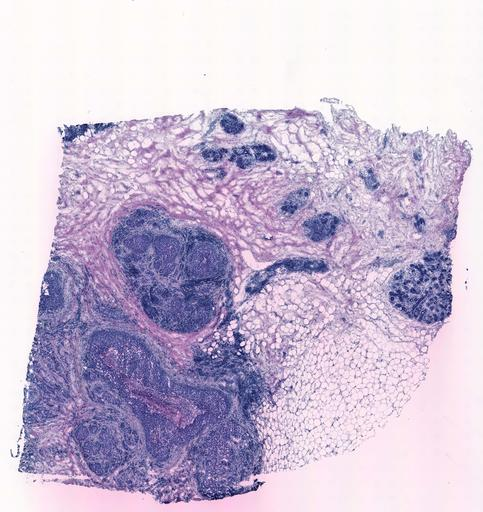

Spatial Transcriptomics H&E image

As you are no pathologists (I sure ain’t!), the image by itself might not tell you much, but looking at this one, it’s fairly easy to see where the tumor areas are. Traditionally, if one where to use “bulk” RNAseq (i.e. take RNA from the whole tissue section), there would be no distinction of different tumor areas, as they would be mixed togheter.

## 1.2 Load the data

As in lab3, we will use the Seurat package to store our data. Start by downloading the count data and the tissue image from Canvas, and load the count data into r:

```r
# Load the count data
```

Lets look at our column-names here. In previous labs, columns represent “samples” or “cells”. Here, they represent a spatial “spot”, i.e. a circular area on the array where the RNA were captured. Look at some of the column names. You will notice that they are in the form of coordinates ([x-coordinate]x[y-coordinate]), representing the position on the ST array. This information can be used to plot the data in R.

## 1.3 Filter out low abundance genes.

There are quite a lot of genes here with very low count values across the tissue. These will be both hard to analyze (risk for dropout-events) as well as increase our computational time. So lets filter them out. Set a threshold for 10 gene-counts across all spots.

```r
# Filter your count matrix
```

## 1.4 Create the Seurat object

ST data is not single cells (one spatial “spot” contains 10 cells on average), but the characteristics of the data do in many ways display similarity to that seen in single cell assays. Hence, many of the methods we use to deal with ST data at our lab are methods originally developed with singe cell data in mind (like the Seurat workflow).

Lets create a Seurat object to handle our data.

```r
# Create Seurat object
```

### 1.4.1 Spot filtering

We also want to remove capture-spots with too few counts, se a threshold of 500 total counts as minimum value for each spot.

```r
# Load the count data
```

Print your Seurat object and make sure you have 9898 genes and 557 samples left

## 1.5 Normalize the data

Lets use the same Seurat workflow as in lab3 (SCTransform)

```r
# Transform the data
```

## 1.6 Plot the data

As you noted, the spatial coordinates are saved in the column names of the count file. These can be extracted and used as coordinates for our plots. I’ve provided some code below to extract this information. You can use my code or try it yourself, it’s not really needed to understand this code if you don’t want to ;)

Basically, I extract the x and y coordinates and create a data frame with them that I use for plotting:

```r
spotNames <- colnames(se)
spotNames <- sapply(strsplit(spotNames, "_"), "[[", 1)
xcoord = as.numeric(sapply(strsplit(spotNames, "x"), "[[", 1))
ycoord = as.numeric(sapply(strsplit(spotNames, "x"), "[[", 2))
coord_df = as.data.frame(cbind(x=xcoord, y=ycoord))

plot(x=xcoord, y=-ycoord, col="black", lwd=5, asp=1,
             ylab="", xlab="", main=paste("Tissue plot"), pch=7, cex.main=3,
             xaxt="n", yaxt="n", bty="n", col.main="black")
```

[output not shown]

Do you recognize the plot? Notice all the “extra” things I add to the plot function, that is just to remove axis, labels etc.

```r
# Answer the question - What are we looking at and why is there holes in the plot?
```

### 1.6.1 Color a specific gene

Lets explore what we can actually do with the fact that we have spatial information along our gene expression data.

Begin by finding the most variable gene in your data across the spots (hint: use `var()` and apply it to all rows). OBS! Use your normalized/transformed data and not your raw values

```r
#Calculate the most variable genes and save that as a vector
```

### 1.6.2 Plot the gene and color it by the normalized counts

In order to make a color gradient, we can use the function `colorRampPalette` and set the color range between two colors (low and high). First, extract the normalized count values from your *4th most variable gene* and save that to a vector.

```r
#extract the normalized count values from your _4th most variable gene_ and save that to a vector, call the vector "col"
```

Then, we will use this vector to create our color gradient (I’ve given you the code below):

```r
rbPal <- colorRampPalette(c('yellow','red'))
color_vector <- rbPal(10)[as.numeric(cut(col,breaks = 10))]
```

Now, we can do the same plot as before, but instead color the points with the color vector! Also, but the name of the gene as the main title of the plot ! (Hint: you can use the plot code above and change the color part and the title part)

```r
#Plot the gene expression
```

### 1.6.3 Plot the data with the tissue image below

One of the main features with ST data is that you can overlay your data on top of the tissue image, in order to visualize the spatial location of the data points. Below I give you a function for such a plot. Load in the function in R (i.e. just copy and run the code), and run the function with your data and your image file (downloaded from canvas and loaded into R (see next chunk)). OBS: you might need to install the `ggplot2` library before (and load it)

```r
#This is the code to load the image.
#OBS! You need the "jpeg" package, install if you do not have that!
library(jpeg)
library(ggplot2)
tissue <- jpeg::readJPEG("data_lab4/he_image.jpg")
tissue_grob <- grid::rasterGrob(tissue,
                                    width = unit(1, "npc"),
                                    height = unit(1, "npc"),
                                    interpolate = TRUE
                                )
```

The plot function:

```r
arrayPlot <- function(coordinates, image = NULL) {

    xmin=1
    xmax=33
    ymin=1
    ymax=35

    annotation <- ggplot2::annotation_custom(image, -Inf, Inf, -Inf, Inf)

    coordinates$y <- ymax - coordinates$y + ymin

    ggplot(data=coordinates, aes(x=x, y=y)) +
       annotation +
        geom_point(col="black",
            alpha = 0.5, size=8
        ) +
        coord_fixed() +
        scale_x_continuous(expand = c(0, 0), limits = c(xmin, xmax)) +
        scale_y_continuous(expand = c(0, 0), limits = c(ymin, ymax)) +
        theme_bw() +
        theme(
            axis.text = element_blank(),
            axis.title = element_blank(),
            axis.ticks = element_blank()
        )
}
```

Now you can use the function that you just “created”:

```r
arrayPlot(coord_df, image=tissue_grob)
```

[output not shown]

Color the same gene as before above the tissue! (Using the new function, try to figure out where to put the color vector)

```r
#Color the same gene as before above the tissue
```

## 1.7 Cluster the data

Lets cluster our spatial areas with kMeans and visualize it on the array. Use 5 clusters.

```r
#Run Kmeans on the transformed count values
```

Remember that clusters are stored in the output of kmeans (e.g. if you type km <- kmeans()) they are found in km$cluster)

If you want to create a color palette out of this, create a color vector via `palette()[km$cluster]`. After running this, you might as well save the color information to the seurat object, e.g:

```r
se@meta.data$clusterColor <- palette()[km$cluster]
```

## 1.8 Difference in genes among regions

Lets conduct a differential gene expression analysis between two areas. We can do this in Seurat with the `FindMarkers` function. To use this function, we first need to save the cluster assignments as “Idents” in the Seurat object:

```r
Idents(object = se) <- se@meta.data$clusterColor
```

The function can then be used like this:

`FindMarkers(se, ident.1 = "green", ident.2 = "black")`

Now run a DEA between the tumor area (hint: one of several tumor areas are in the middle of the tissue) and the non-tumor area located at the far right of the tissue (which is cell dense) with the FindMarkers function.

```r
# run a DEA between the tumor area and the non-tumor area located at the far right of the tissue (which is cell dense)
```

You will get a table with pvalues and average logFoldChange.

### 1.8.1 Extract the 5 top upregulated genes in the tumor area

Sort this table by adjusted-pvalue and print the answer

```r
# Print the 5 most differentialy expressed genes
```

Choose a gene that you think is “cancer-associated” and make an arrayplot with the expression of that gene as overlay.

```r
# Make an arrayplot with the choosen gene expression
```